# Diari 3 - Posada en comú i focalització

JHJ

29/11/2024

## Pre-Processament de les dades

```r
simulacions = mutate(simulacions[c(1,2)], simulacions[c(3,4,5,6,7,8)]*60)
```

## Qüestions abordades

*Escriviu les qüestions que heu decidit abordar.*

1. Quina és la forma dels errors, és a dir, si els errors segueixen una forma lineal, logarítmica, exponencial, etc…?
2. Com podem modelar la v.a. `temps d'execució` d’un algoritme?

## Comentaris

*Qualsevol cosa que vulgueu afegir sobre les qüestions.*

Sobre la qüèstio **1**: definim la v.a. $T_i = \text{"Temps d'execució de l'algoritme i"}$, i definim també la funció següent com.

$$T_i = f(n) + E\text{, on T_i i E són v.a.'s, i E} \approx \text{a un
cert model x}$$

On $f(n)$ la definim com.

$$f(n) = \alpha + \beta \cdot n + \gamma \cdot n^2\text{, on }n^2\text{
correspon a la forma dels errors}$$

Llavors només hauríem de trobar els valors/coeficients $\alpha, \beta, \gamma$, aquests valors amb R els podem obtenir mitjançant la funció `coef()`, la qual accepta com a paràmetre un model.

> Recordatori: Un model sempre té dues parts.
> - **Part determinista** $\rightarrow$ és la forma o línia que surt de la v.a.
> - **part aleatòria** $\rightarrow$ són errors que surten de l’ajust de la v.a.

## Variables relacionades

*Quines variables del vostre conjunt de dades, o d’altres, us sembla que caldrà considerar?*

Del nostre conjunt de dades caldrà considerar el temps d’execució de cada algoritme, que serien les variables que volem estudiar (variables resposta o depenents), i entre les variables independents o explicatives, cal considerar la mida del vector.

> **Amplació del conjunt de dades**. En aquesta part ens ha semblat que era interessant ampliar el nostre conjunt de dades per incloure proves de cada algoritme amb vectors ordenats, *a més de les proves amb vectors desordenats que ja teníem*.

> D’aquesta manera podrem saber si els algoritmes del nostre conjunt tenen més errors amb vectors ordenats o desordenats? O com és la forma dels errors amb vectors ordenats i desordenats? Canvia molt? O és més estable?

> Per tal de donar resposta a les preguntes anteriors hem ampliat el nostre conjunt de dades.

## Resultats

*Resums i gràfics obtinguts.*

Per respondre a la qüèstio **1**, podem començar calculant l’SQT *o suma de quadrats totals*, i d’aquesta manera tindrem una idea de la variabilitat i la variància dels temps d’execució de cada algoritme *amb vectors desordenats*.

```r
SQT = tibble(
  bubblesort = sum((simulacions$bubblesort - mean(simulacions$bubblesort))^2),
  quicksort = sum((simulacions$quicksort - mean(simulacions$quicksort))^2),
  mergesort = sum((simulacions$mergesort - mean(simulacions$mergesort))^2)
)
SQT
```

```
## # A tibble: 1 × 3
##   bubblesort quicksort mergesort
##        <dbl>     <dbl>     <dbl>
## 1       62.4   0.00265    0.0193
```

I amb vectors ordenats.

```r
SQT.ord = tibble(
  bubblesort = sum((simulacions$ord.bubblesort - mean(simulacions$ord.bubblesort))^2),
  quicksort = sum((simulacions$ord.quicksort - mean(simulacions$ord.quicksort))^2),
  mergesort = sum((simulacions$ord.mergesort - mean(simulacions$ord.mergesort))^2)
)
SQT.ord
```

```
## # A tibble: 1 × 3
##   bubblesort quicksort mergesort
##        <dbl>     <dbl>     <dbl>
## 1       19.7     0.211   0.00903
```

A partir d’aquí podem veure que tant per vectors desordenats com ordenats el que més errors *totals* causa seria bubblesort, i el que menys seria quicksort *cas vectors desordenats* o mergesort *cas vectors ordenats*, però també podem veure que bubblesort i mergesort minimitzen els errors **amb vectors ordenats**, al contrari de quicksort que causa més errors quan els vectors estan **ordenats**. De moment, el comportament dels algoritmes és l’esperat.

El següent pas és ajustar un model lineal que ajusti/minimitzi els errors entre el temps de cada algoritme **amb vectors desordenats** amb la funció $f(n)$ *definida als comentaris* amb la forma que segueixen els errors de cada algoritme, per exemple: bubblesort podria ser de la forma de $(n^2)$, i mergesort i quicksort haurien de tenir la forma $(n \cdot log(n))$, tot i que quicksort és de $O(n^2)$ **en el cas pitjor** .

```r
mods = list(
  lm.bubblesort = lm(bubblesort~mida+I(mida^2), data = simulacions),
  lm.quicksort = lm(quicksort~mida+I(mida*log(mida)), data = simulacions),
  lm.mergesort = lm(mergesort~mida+I(mida*log(mida)), data = simulacions)
)
```

I amb vectors ordenats.

```r
mods.ord = list(
  lm.bubblesort = lm(ord.bubblesort~mida+I(mida^2), data = simulacions),
  lm.quicksort = lm(ord.quicksort~mida+I(mida^2), data = simulacions),
  lm.mergesort = lm(ord.mergesort~mida+I(mida*log(mida)), data = simulacions)
)
```

I podem visualitzar els models ajustats amb la funció `ggplot()`.

#### BubbleSort

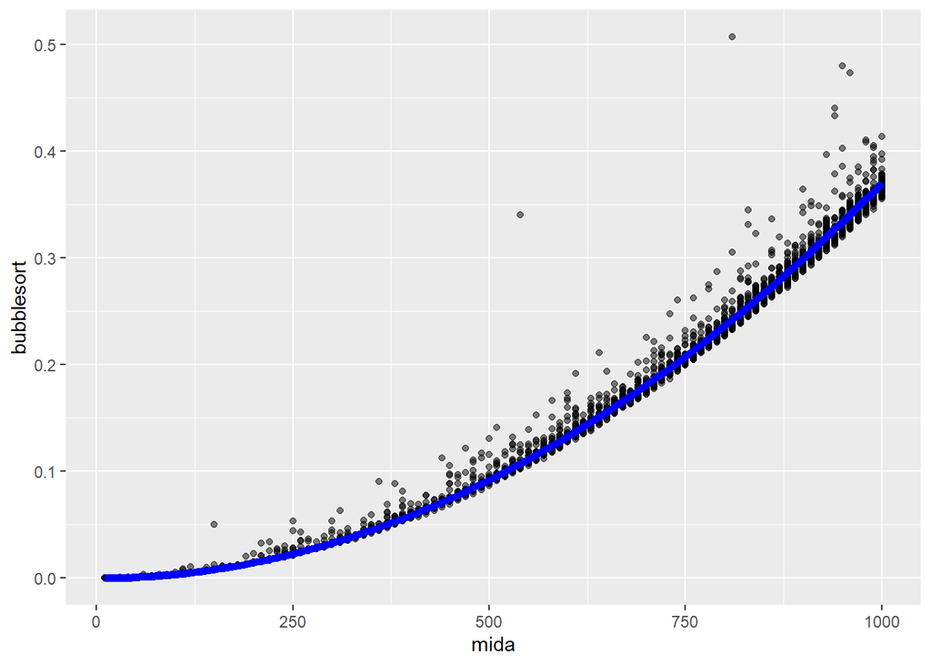

```r
ggplot(data = simulacions, aes(x = mida, y = bubblesort)) +
  geom_point(alpha = 0.5) +
  geom_function(fun = function(x) predict(mods$lm.bubblesort, newdata = list(mida = x)), col = 'blue', linewidth = 2)
```

#### QuickSort

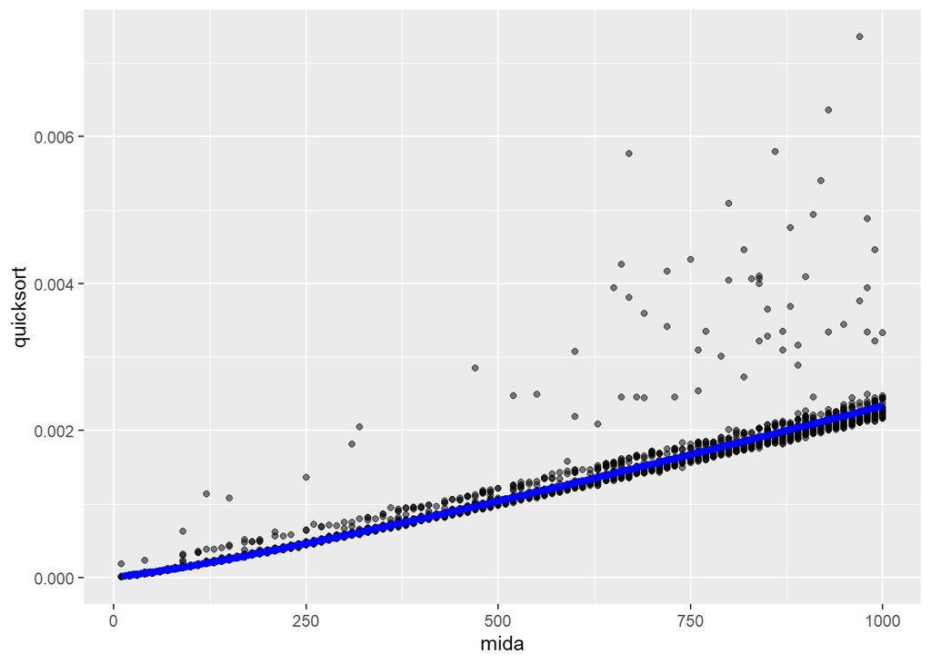

```r
ggplot(data = simulacions, aes(x = mida, y = quicksort)) +
  geom_point(alpha = 0.5) +
  geom_function(fun = function(x) predict(mods$lm.quicksort, newdata = list(mida = x)), col = 'blue', linewidth = 2)
```

#### MergeSort

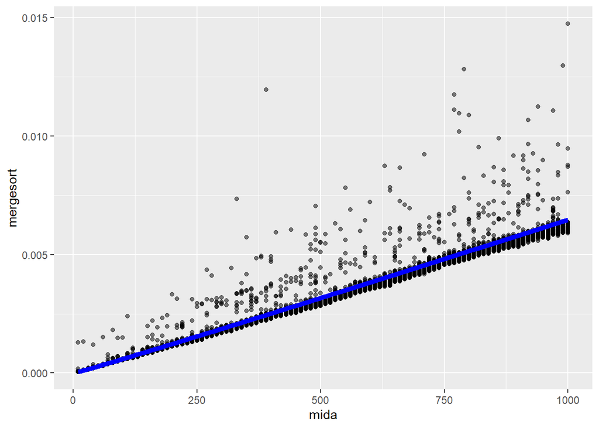

```r
ggplot(data = simulacions, aes(x = mida, y = mergesort)) +
  geom_point(alpha = 0.5) +
  geom_function(fun = function(x) predict(mods$lm.mergesort, newdata = list(mida = x)), col = 'blue', linewidth = 2)
```

I també podem visualitzar els models ajustats dels temps quan els vectors estan ordenats.

#### BubbleSort *ordenat*

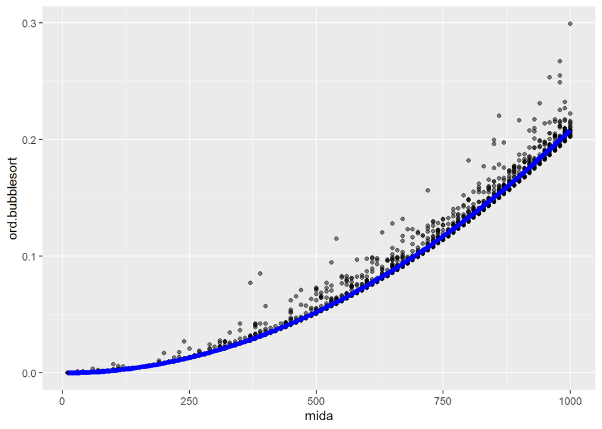

```r
ggplot(data = simulacions, aes(x = mida, y = ord.bubblesort)) +
  geom_point(alpha = 0.5) +
  geom_function(fun = function(x) predict(mods.ord$lm.bubblesort, newdata = list(mida = x)), col = 'blue', linewidth = 2)
```

#### QuickSort *ordenat*

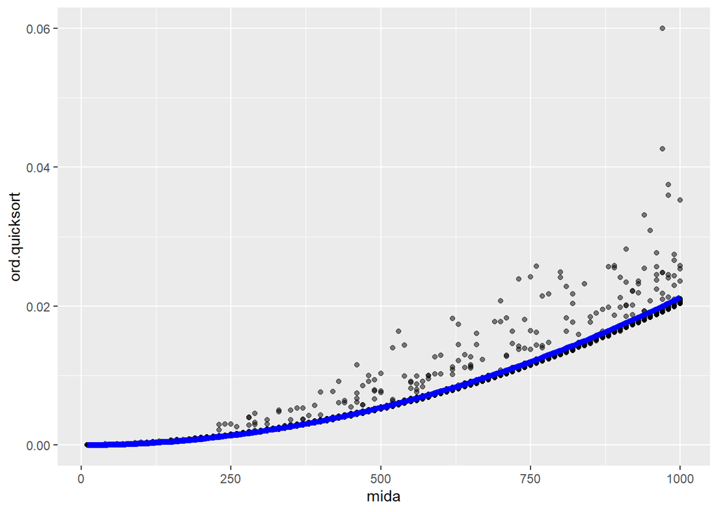

```r
ggplot(data = simulacions, aes(x = mida, y = ord.quicksort)) +
  geom_point(alpha = 0.5) +
  geom_function(fun = function(x) predict(mods.ord$lm.quicksort, newdata = list(mida = x)), col = 'blue', linewidth = 2)
```

#### MergeSort *ordenat*

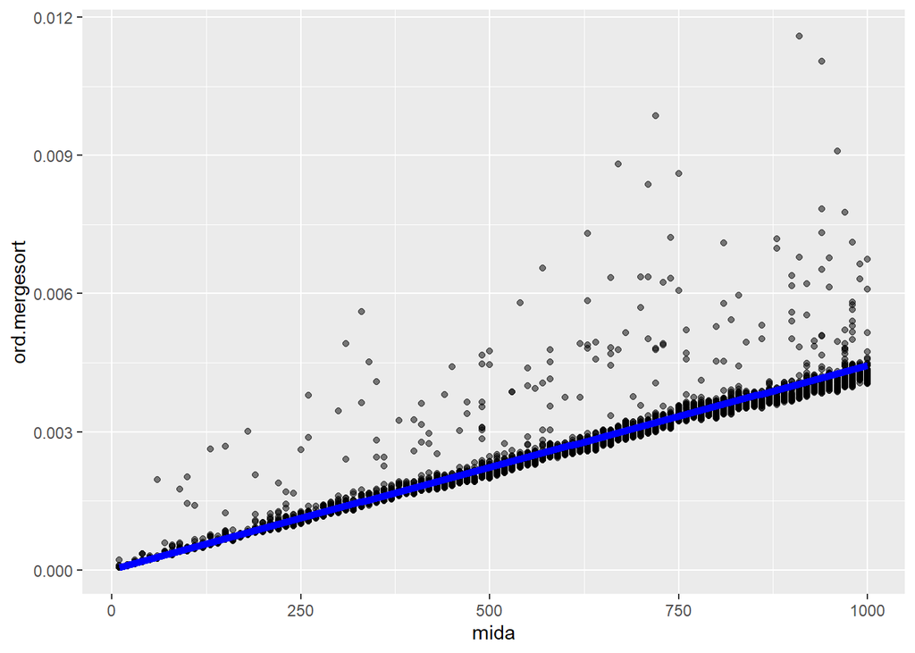

```r
ggplot(data = simulacions, aes(x = mida, y = ord.mergesort)) +
  geom_point(alpha = 0.5) +
  geom_function(fun = function(x) predict(mods.ord$lm.mergesort, newdata = list(mida = x)), col = 'blue', linewidth = 2)
```

I abans d’estudiar els residus (errors), podem calcular els errors que no hem explicat *o l’SQR*.

Per vectors desordenats.

```r
SQR1 = tibble(
  bubblesort = sum((residuals(mods$lm.bubblesort))^2),
  quicksort = sum((residuals(mods$lm.quicksort))^2),
  mergesort = sum((residuals(mods$lm.mergesort))^2)
)
SQR1
```

```
## # A tibble: 1 × 3
##   bubblesort quicksort mergesort
##        <dbl>     <dbl>     <dbl>
## 1      0.449  0.000271   0.00162
```

I per vectors ordenats.

```r
SQR2 = tibble(
  bubblesort = sum((residuals(mods.ord$lm.bubblesort))^2),
  quicksort = sum((residuals(mods.ord$lm.quicksort))^2),
  mergesort = sum((residuals(mods.ord$lm.mergesort))^2)
)
SQR2
```

```
## # A tibble: 1 × 3
##   bubblesort quicksort mergesort
##        <dbl>     <dbl>     <dbl>
## 1      0.119   0.00720  0.000883
```

I per calcular la proporció d’errors que hem aconseguit explicar amb cadascun dels models, podem calcular el coeficient de determinació $R^2$ seguint la fórmula.

$$R^2 = \frac{SQM}{SQT} = 1 - \frac{SQR}{SQT}$$

> **SQM** és la part de l’SQT que sabem explicar, i **SQR** és la part de l’SQT que **NO** sabem explicar.

```r
tibble(
  bubblesort = 1 - (SQR1$bubblesort/SQT$bubblesort),
  quicksort = 1 - (SQR1$quicksort/SQT$quicksort),
  mergesort = 1 - (SQR1$mergesort/SQT$mergesort)
)
```

```
## # A tibble: 1 × 3
##   bubblesort quicksort mergesort
##        <dbl>     <dbl>     <dbl>
## 1      0.993     0.898     0.916
```

```r
tibble(
  bubblesort = 1 - (SQR2$bubblesort/SQT.ord$bubblesort),
  quicksort = 1 - (SQR2$quicksort/SQT.ord$quicksort),
  mergesort = 1 - (SQR2$mergesort/SQT.ord$mergesort)
)
```

```
## # A tibble: 1 × 3
##   bubblesort quicksort mergesort
##        <dbl>     <dbl>     <dbl>
## 1      0.994     0.966     0.902
```

On veiem que hem explicat més errors amb els models que ajusten el temps *amb vectors ordenats* que amb vectors desordenats, a excepció de mergesort, que expliquem més errors amb vectors desordenats. Per tant, podríem dir que els models ajustats són bons models, ja que expliquen prop del $90\%$ dels errors de l’SQT.

I a continuació, ja podem començar a estudiar la forma dels errors, podríem començar visualitzant-los amb l’histograma.

```r
errors.bubblesort = data.frame(valors.ajustats = fitted(mods$lm.bubblesort), residus = residuals(mods$lm.bubblesort))
errors.quicksort = data.frame(valors.ajustats = fitted(mods$lm.quicksort), residus = residuals(mods$lm.quicksort))
errors.mergesort = data.frame(valors.ajustats = fitted(mods$lm.mergesort), residus = residuals(mods$lm.mergesort))
```

#### BubbleSort `desordenat`

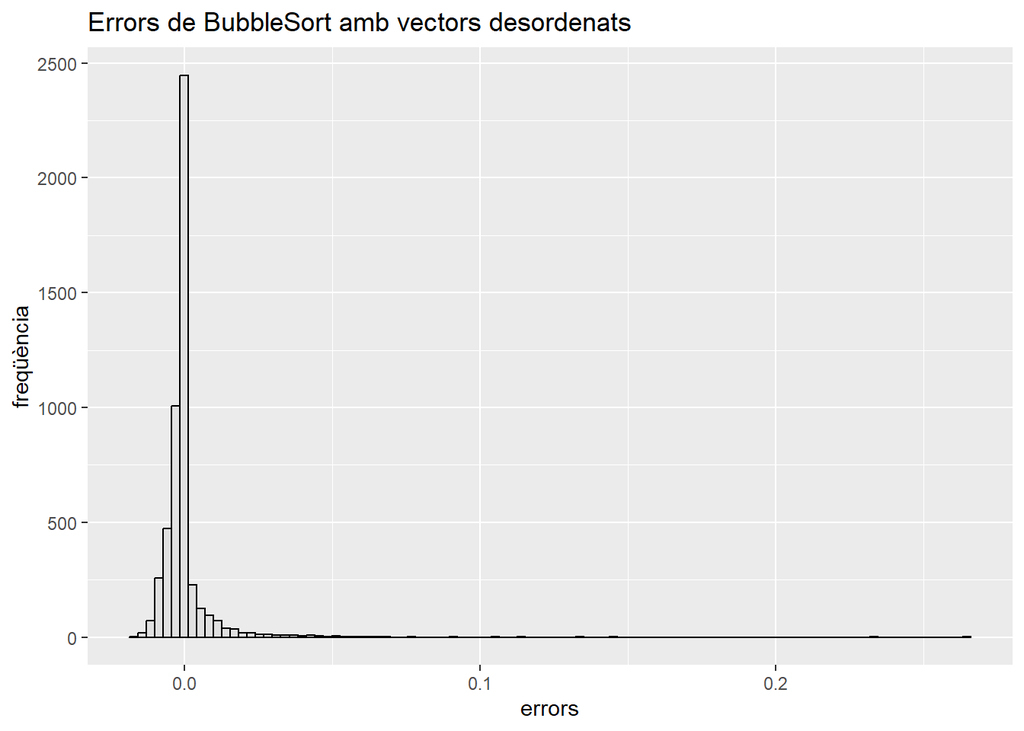

```r
ggplot(data = errors.bubblesort, aes(x = residus)) +
  geom_histogram(bins = 100, col = 'black', fill = "#E0E0E0") +
  labs(x = 'errors', y = 'freqüència', title = 'Errors de BubbleSort amb vectors desordenats')
```

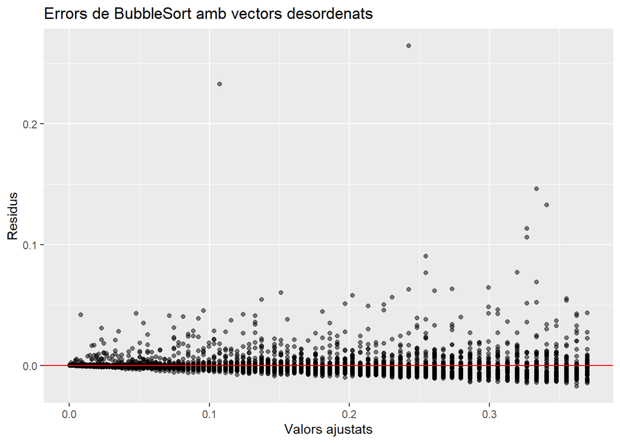

```r
ggplot(errors.bubblesort, aes(x = valors.ajustats, y = residus)) +
  geom_point(alpha = 0.5) +
  geom_hline(yintercept = 0, color = "red") +
  labs(x = "Valors ajustats", y = "Residus", title = "Errors de BubbleSort amb vectors desordenats")
```

#### QuickSort `desordenat`

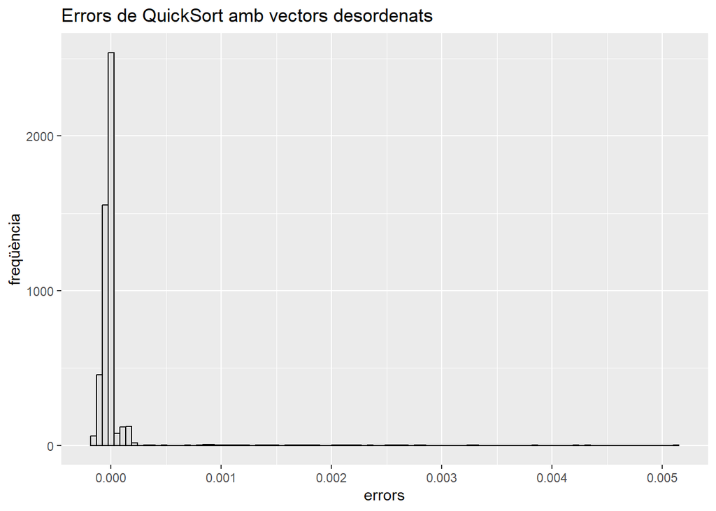

```r
ggplot(data = errors.quicksort, aes(x = residus)) +
  geom_histogram(bins = 100, col = 'black', fill = "#E0E0E0") +
  labs(x = 'errors', y = 'freqüència', title = 'Errors de QuickSort amb vectors desordenats')
```

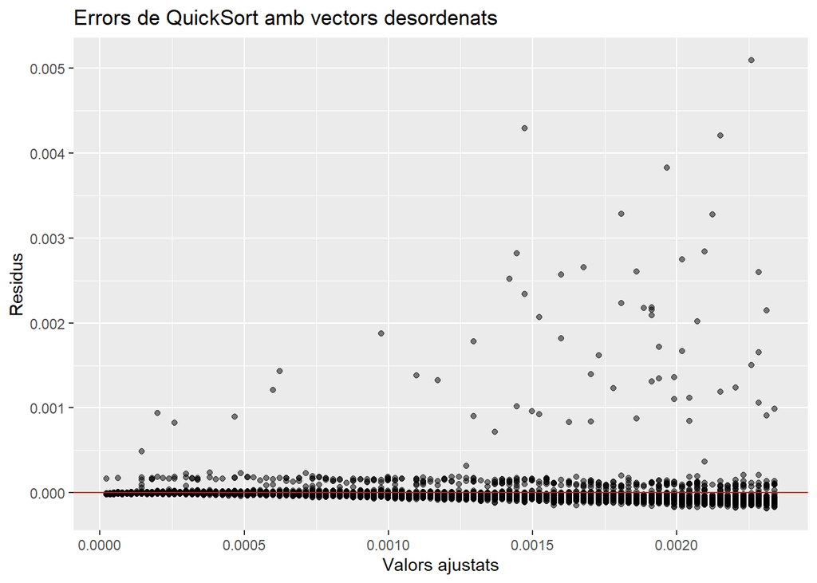

```r
ggplot(errors.quicksort, aes(x = valors.ajustats, y = residus)) +
  geom_point(alpha = 0.5) +
  geom_hline(yintercept = 0, color = "red") +
  labs(x = "Valors ajustats", y = "Residus", title = "Errors de QuickSort amb vectors desordenats")
```

#### MergeSort `desordenat`

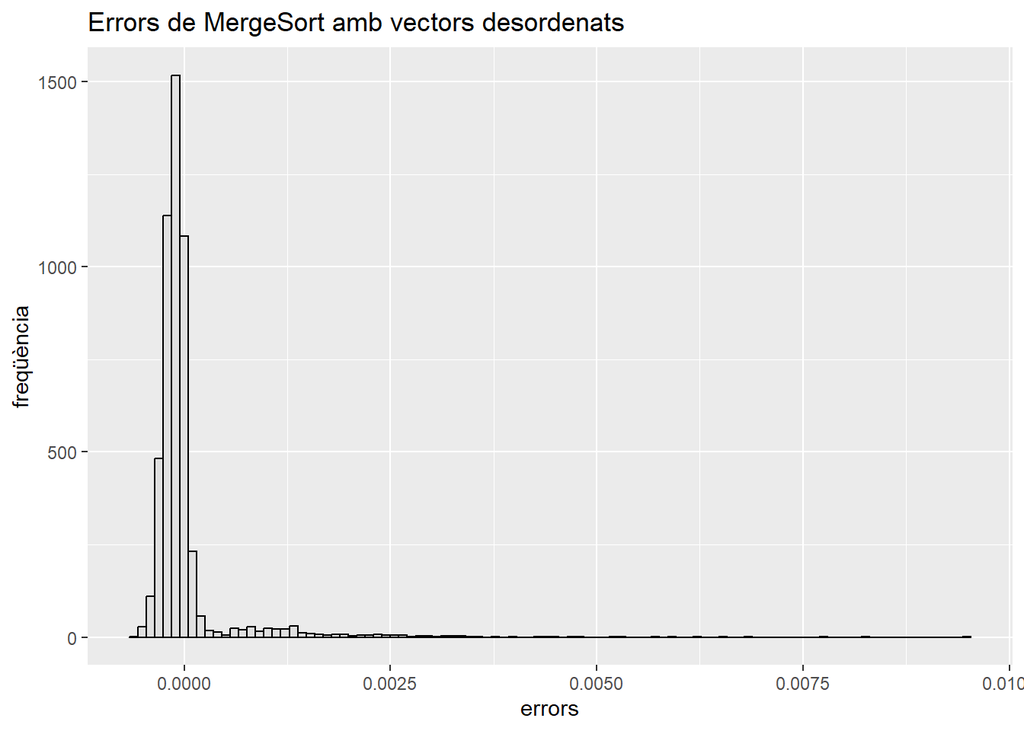

```r
ggplot(data = errors.mergesort, aes(x = residus)) +
  geom_histogram(bins = 100, col = 'black', fill = "#E0E0E0") +
  labs(x = 'errors', y = 'freqüència', title = 'Errors de MergeSort amb vectors desordenats')
```

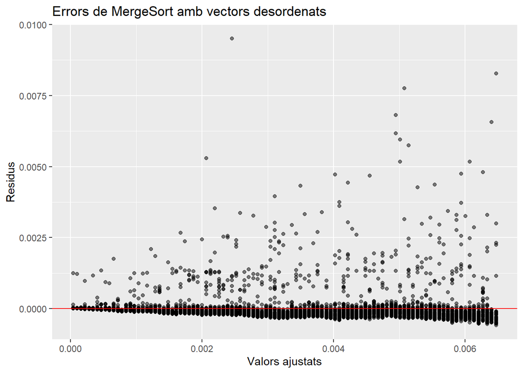

```r
ggplot(errors.mergesort, aes(x = valors.ajustats, y = residus)) +
  geom_point(alpha = 0.5) +
  geom_hline(yintercept = 0, color = "red") +
  labs(x = "Valors ajustats", y = "Residus", title = "Errors de MergeSort amb vectors desordenats")
```

```r
errors.bubblesort = data.frame(valors.ajustats = fitted(mods.ord$lm.bubblesort), residus = residuals(mods.ord$lm.bubblesort))
errors.quicksort = data.frame(valors.ajustats = fitted(mods.ord$lm.quicksort), residus = residuals(mods.ord$lm.quicksort))
errors.mergesort = data.frame(valors.ajustats = fitted(mods.ord$lm.mergesort), residus = residuals(mods.ord$lm.mergesort))
```

#### BubbleSort `ordenat`

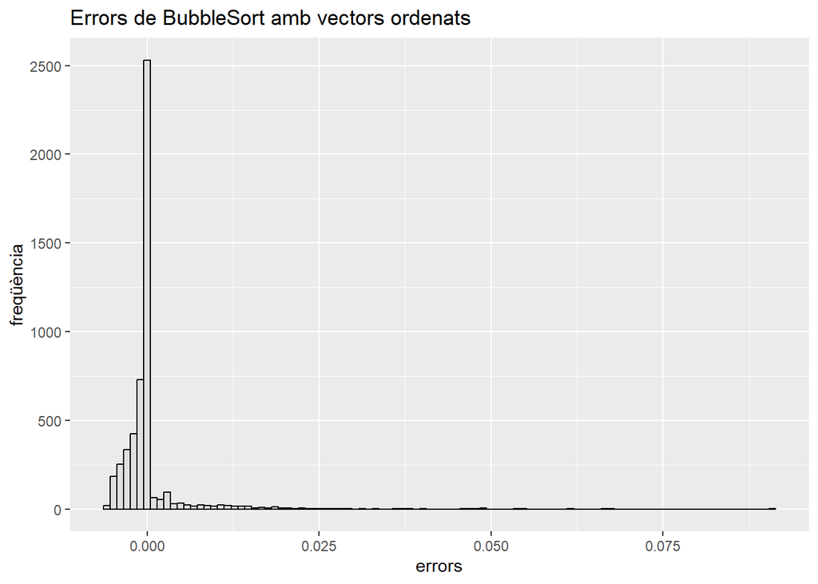

```r
ggplot(data = errors.bubblesort, aes(x = residus)) +
  geom_histogram(bins = 100, col = 'black', fill = "#E0E0E0") +
  labs(x = 'errors', y = 'freqüència', title = 'Errors de BubbleSort amb vectors ordenats')
```

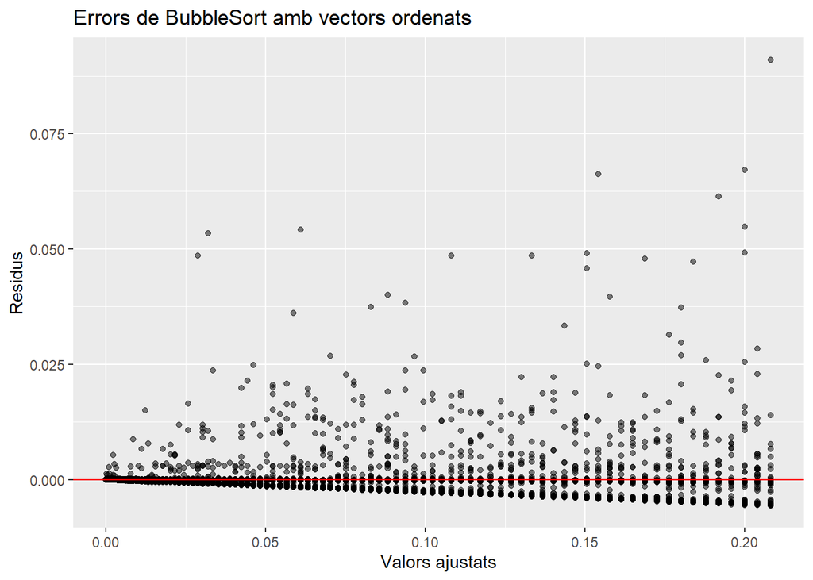

```r
ggplot(errors.bubblesort, aes(x = valors.ajustats, y = residus)) +
  geom_point(alpha = 0.5) +
  geom_hline(yintercept = 0, color = "red") +
  labs(x = "Valors ajustats", y = "Residus", title = "Errors de BubbleSort amb vectors ordenats")
```

#### QuickSort `ordenat`

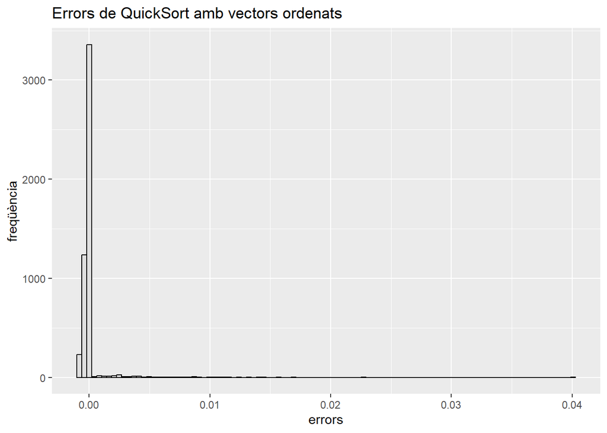

```r
ggplot(data = errors.quicksort, aes(x = residus)) +
  geom_histogram(bins = 100, col = 'black', fill = "#E0E0E0") +
  labs(x = 'errors', y = 'freqüència', title = 'Errors de QuickSort amb vectors ordenats')
```

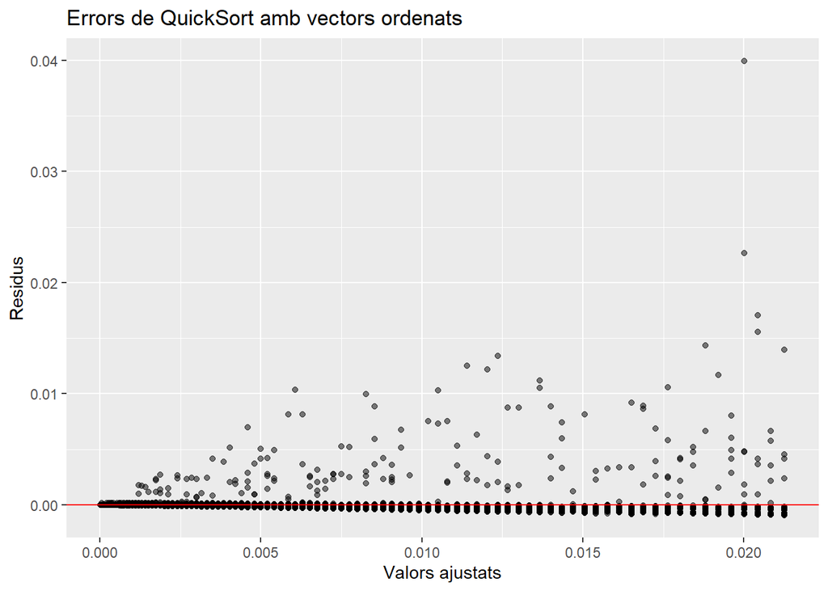

```r
ggplot(errors.quicksort, aes(x = valors.ajustats, y = residus)) +
  geom_point(alpha = 0.5) +
  geom_hline(yintercept = 0, color = "red") +
  labs(x = "Valors ajustats", y = "Residus", title = "Errors de QuickSort amb vectors ordenats")
```

#### MergeSort `ordenat`

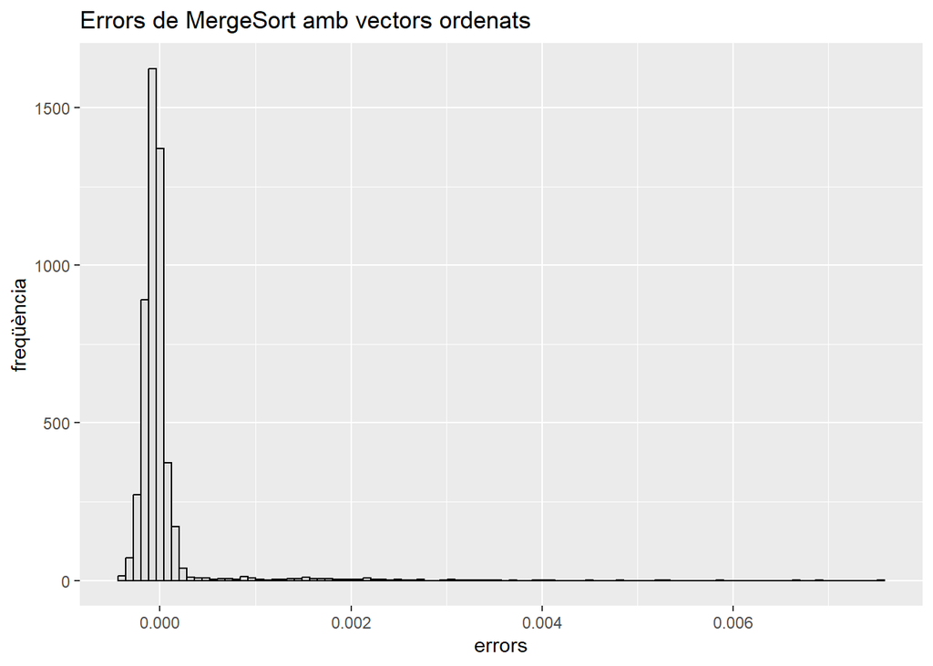

```r
ggplot(data = errors.mergesort, aes(x = residus)) +
  geom_histogram(bins = 100, col = 'black', fill = "#E0E0E0") +
  labs(x = 'errors', y = 'freqüència', title = 'Errors de MergeSort amb vectors ordenats')
```

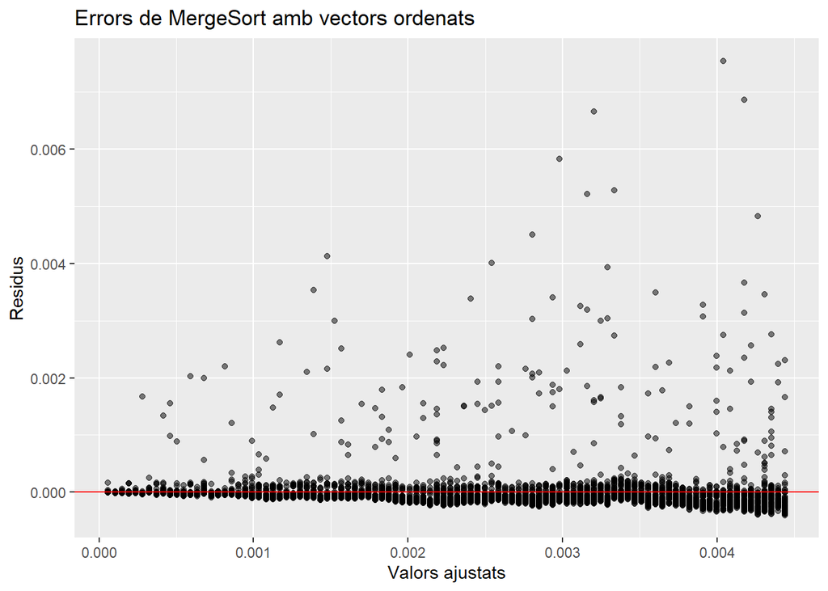

```r
ggplot(errors.mergesort, aes(x = valors.ajustats, y = residus)) +
  geom_point(alpha = 0.5) +
  geom_hline(yintercept = 0, color = "red") +
  labs(x = "Valors ajustats", y = "Residus", title = "Errors de MergeSort amb vectors ordenats")
```

Conclusió, podríem dir que bubblesort i mergesort són els que semblen més estables, a diferència de quicksort que és el que causa més errors amb vectors ordenats, sobre la forma, tots semblen seguir **una normal amb mitjana a prop del 0**, o una exponencial amb $\lambda = \frac{1}{\overline{x}}$, on $\overline{x}$ és la mitjana dels errors.

Observant tots els gràfics, també podem veure una relació entre els temps o els errors i la mida, i podem dir que com més gran és el vector, es produeixen més errors, és a dir, per vectors grans hi hauran més errors, i per vectors petits hi hauran menys errors.

## Noves qüestions

*Dubtes, preguntes i qüestions que han sorgit durant l’estudi.*

1. Els algoritmes segueixen l’ordre que haurien de seguir *segons la teoria*, p.ex. bubblesort és $O(n^2)$, i quicksort i mergesort són $O(n \cdot log(n))$? *La resposta s’obté veient els gràfics del principi*.
2. Quin algorisme és més estable, és a dir, tenen la mateixa eficiència per vectors desordenats, com per vectors ordenats?
3. Podem trobar un model que ajusti millor els temps d’execució dels algoritmes, és a dir, un model que millori l’$R^2$?
4. Hi ha alguna altra manera, *a part de l’$R^2$*, de saber si els models ajustats són bons models, és a dir, si ajusten prou bé els temps d’execució? Perquè si afegim variables i interacció a un model potser que millorem l’$R^2$, però aquest no és l’únic criteri, també podriem fer servir un altre criteri com l’AIC per tal de saber si els models ajustats ajusten prou bé els temps d’execució, o hauríem de buscar un altre model.

## Material addicional

*Opcional, si heu consultat alguna web o font. Indiqueu els enllaços.*

## Llista de tasques

*Opcional, si us va bé anar indicant les feines que cal fer i com les penseu repartir entre els membres de l’equip.*